# 2026 Spring BIO 2100 Midterm Creation and Answers

33 points

## Instructions! Read this first.

The exam is open note, open course website, open class-related code repositories (mine and those you produced in class). However, you may not get external help ( from other students, AI, directed internet searches, etc.). Please update the statement below to acknowledge these instructions (and that you can use git).

I, INSERT YOUR NAME HERE, promise to not seek external help on the exam. I understand any academic issues will result in a D or F on the exam or in the class and be reported to the Dean of Students. Infractions will also result in me being unable to obtain a letter of recommendation from the department for professional school applications.

For all questions, the statement is based on what you might hear from a colleague (e.g., “How do I analyze this?”). This is like when you get a call to review a paper. Please answer questions succinctly but with necessary details on all required steps/concerns you might need to consider.

While the exam is based on a realistic scenario (with citations), some data and scenarios are fictional and contrived for the exam (i.e., don’t quote all this as fact!).

Good luck!

## Background

Where do bees go in the winter? And how do they survive?

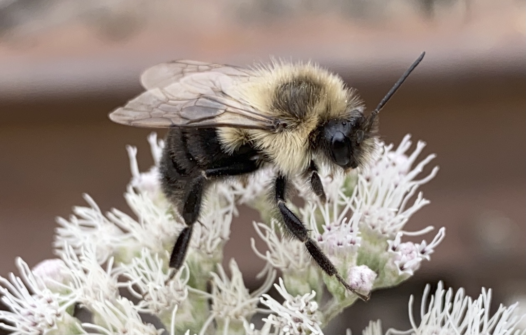

Bombus impatiens, the common eastern bumblebee. Photographed in New Jersey. By Mousebelt - Own work, CC BY-SA 4.0, https://commons.wikimedia.org/w/index.php?curid=98700493

New common eastern bumblee (*Bombus impatiens*) queens (gynes) nest underground after mating in the fall. They start new colonies the following spring. Given that, how do they survive rain and snow during their hibernation, which may last for months?

A lab accident led to the discovery that bees may be able to survive submersion (“Hibernating Bumblebee Queens Can Survive Underwater for up to a Week, Study Finds,” n.d.).

## 1

During an experiment focused on the impact of insecticides on common eastern bumblebees, a graduate student was keeping bee queens in soil-filled tubes in the refrigerator (to mimic winter conditions). One day she noticed some of the tubes were filled with water. She quickly removed the bees but expected them to be dead. Instead, 20 out of 21 were still moving.

This may be an example of where statistics is not needed. Why?

## 2

An editor suggested a short comment noting these results should have a p-value (probably a bad idea..). However, how would you use statistics to analyze the data. Make sure you include

- null hypothesis (1 point)
- alternative hypothesis (1 point)
- explanation for test you will use (1.5 point)
- results from statistical test (1 point)

  ```r
  binom.test(20,21,0)
  ```

  ```
      Exact binomial test

  data:  20 and 21
  number of successes = 20, number of trials = 21, p-value < 2.2e-16
  alternative hypothesis: true probability of success is not equal to 0
  95 percent confidence interval:
   0.7618401 0.9987951
  sample estimates:
  probability of success
                0.952381
  ```

```r
binom.test(20,21,0, alternative= "greater")
```

```
    Exact binomial test

data:  20 and 21
number of successes = 20, number of trials = 21, p-value < 2.2e-16
alternative hypothesis: true probability of success is greater than 0
95 percent confidence interval:
 0.7932746 1.0000000
sample estimates:
probability of success
              0.952381
```

- clear explanation of how results relate to your stated hypotheses (1.5 point)

## 3

A fellow student is confused about your analysis. They focused on mortality (opposite of survival) and found a signal of 0.047619 in the data and took that as p. Why is your value different? Make sure you explain what a p-value is!

## 4

Note during creation: understand the data

```r
bee_data <- read.csv("Data_flooding.csv", stringsAsFactors = T)
```

```r
summary(bee_data)
```

```
     Bee_ID    Maternal_colony     Weight           Submersion  Duration
 A01    :  3   B: 54           Min.   :303.0   ctl       : 51   24 :126
 B70    :  3   C:123           1st Qu.:702.0   floating  :189   7  :126
 B71    :  3   D:186           Median :783.0   underwater:189   8  :126
 B72    :  3   E: 66           Mean   :771.5                    N/A: 51
 B73    :  3                   3rd Qu.:857.0
 B74    :  3                   Max.   :961.0
 (Other):411                   NA's   :42
             Tx          Time          Survival
 ctl          :51   Min.   :1.000   Min.   :0.0000
 floating_24  :63   1st Qu.:1.000   1st Qu.:1.0000
 floating_7   :63   Median :4.000   Median :1.0000
 floating_8   :63   Mean   :4.333   Mean   :0.9254
 underwater_24:63   3rd Qu.:8.000   3rd Qu.:1.0000
 underwater_7 :63   Max.   :8.000   Max.   :1.0000
 underwater_8 :63
```

```r
unique(bee_data$Bee_ID)
```

```
  [1] A01  B70  B71  B72  B73  B74  B75  B76  B77  B78  B79  B80  B81  B82  B83
 [16] B84  B85  B86  C14  C15  C22  C23  C25  C28  C30  C33  C34  C35  C36  C37
 [31] C38  C39  C40  C41  C42  C43  C44  C45  C46  C47  C48  C49  C50  C51  C52
 [46] C53  C54  C55  C56  C57  C58  C59  C60  C61  C62  C63  C64  C65  C66  D100
 [61] D101 D102 D103 D104 D105 D106 D107 D108 D111 D113 D117 D118 D49  D50  D51
 [76] D52  D53  D54  D55  D56  D57  D58  D59  D60  D61  D62  D63  D64  D65  D67
 [91] D68  D69  D71  D72  D73  D74  D75  D76  D77  D78  D79  D80  D81  D82  D83
[106] D84  D85  D86  D87  D88  D89  D90  D91  D92  D93  D94  D95  D96  D97  D98
[121] D99  E01a E01b E02a E02b E03a E03b E04a E04b E05a E05b E06a E06b E07a E07b
[136] E08  E09  E10  E11  E12  E13  E14  E15
143 Levels: A01 B70 B71 B72 B73 B74 B75 B76 B77 B78 B79 B80 B81 B82 B83 ... E15
```

143 unique bees

```r
library(Rmisc)
summarySE(bee_data, groupvars = c("Bee_ID"), measurevar = "Weight")
```

```
    Bee_ID N Weight sd se ci
1      A01 3    805  0  0  0
2      B70 3    886  0  0  0
3      B71 3    643  0  0  0
4      B72 3    899  0  0  0
5      B73 3    839  0  0  0
6      B74 3    660  0  0  0
7      B75 3    852  0  0  0
8      B76 3    835  0  0  0
9      B77 3    879  0  0  0
10     B78 3    857  0  0  0
11     B79 3    827  0  0  0
12     B80 3    887  0  0  0
13     B81 3    945  0  0  0
14     B82 3    826  0  0  0
```

[output cut: 129 more lines]

each bee assessed three times

```r
summarySE(bee_data, groupvars = c("Tx"), measurevar = "Weight")
```

```
             Tx  N Weight sd se ci
1           ctl 51     NA NA NA NA
2   floating_24 63     NA NA NA NA
3    floating_7 63     NA NA NA NA
4    floating_8 63     NA NA NA NA
5 underwater_24 63     NA NA NA NA
6  underwater_7 63     NA NA NA NA
7  underwater_8 63     NA NA NA NA
```

17 control, 21 in each duration x submersion treatment

```r
summarySE(bee_data, groupvars = c("Tx", "Duration", "Time"), measurevar = "Weight")
```

```
              Tx Duration Time  N Weight sd se ci
1            ctl      N/A    1 17     NA NA NA NA
2            ctl      N/A    4 17     NA NA NA NA
3            ctl      N/A    8 17     NA NA NA NA
4    floating_24       24    1 21     NA NA NA NA
5    floating_24       24    4 21     NA NA NA NA
6    floating_24       24    8 21     NA NA NA NA
7     floating_7        7    1 21     NA NA NA NA
8     floating_7        7    4 21     NA NA NA NA
9     floating_7        7    8 21     NA NA NA NA
10    floating_8        8    1 21     NA NA NA NA
11    floating_8        8    4 21     NA NA NA NA
12    floating_8        8    8 21     NA NA NA NA
13 underwater_24       24    1 21     NA NA NA NA
14 underwater_24       24    4 21     NA NA NA NA
15 underwater_24       24    8 21     NA NA NA NA
16  underwater_7        7    1 21     NA NA NA NA
17  underwater_7        7    4 21     NA NA NA NA
18  underwater_7        7    8 21     NA NA NA NA
19  underwater_8        8    1 21     NA NA NA NA
20  underwater_8        8    4 21     NA NA NA NA
21  underwater_8        8    8 21     NA NA NA NA
```

A follow-up study submersion (Rondeau and Raine 2024) experiment compared survival under three different conditions.

- **control** (no water)
- **floating** in water
- maintained **underwater** via a plunger

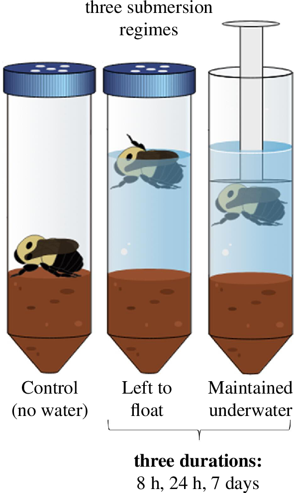

Bees were initially placed in soil filled tubes and refrigerated. After 7 days, submersion treatments were applied. For the treatments with water, bees were maintained for 8 hours, 24 hours, or 7 days. A total of 143 bees (17 control, 21 in each duration x treatment condition) were used. After the experiment, all bees were returned to new tubes with soil, returned to the refrigerator, then assessed for survival at one, four, and eight weeks following the beginning of submersion treatments.

For our exam, we will focus on the data collected at eight weeks following 24 hour submersion treatments. Below code creates a table if you wish to use the combined data. Note the following columns are used

- Submersion
  - treatment (control; floating, underwater =submerged)
- Weight
  - weight in mg (measured before the study)
- Survival
  - 1= survived; 0 = did not survive

```r
bee_data <- read.csv("Data_flooding.csv", stringsAsFactors = T)
library(plyr)
bee_data$Submersion <-revalue(bee_data$Submersion, c("ctl"="control"))
bee_data <- bee_data[bee_data$Time==8 & bee_data$Duration==24 & bee_data$Weight != "NA"|
                       bee_data$Time==8 & bee_data$Submersion=="control" & bee_data$Weight != "NA",]
bee_table <- table(bee_data[bee_data$Time==8 & bee_data$Duration==24|
                       bee_data$Time==8 & bee_data$Submersion=="control","Submersion"],
      bee_data[bee_data$Time==8 & bee_data$Duration==24|
                       bee_data$Time==8 & bee_data$Submersion=="control","Survival"])
colnames(bee_table) <- c("Survived", "Did not survive")
bee_table
```

[output not shown]

Analyze the data. Make sure you include

- null hypothesis (1 point)
- alternative hypothesis (1 point)
- explanation for test you will use (1.5 point)
- results from statistical test (1 point)

  ```r
  chisq.test(bee_table)
  ```

  ```
      Pearson's Chi-squared test

  data:  bee_table
  X-squared = 0.52971, df = 2, p-value = 0.7673
  ```

  ```r
  chisq.test(bee_table)$expected
  ```

  ```
               Survived Did not survive
    control    1.428571        12.57143
    floating   1.938776        17.06122
    underwater 1.632653        14.36735
  ```

  ```r
  fisher.test(bee_table)
  ```

  ```
      Fisher's Exact Test for Count Data

  data:  bee_table
  p-value = 0.8493
  alternative hypothesis: two.sided
  ```

- clear explanation of how results relate to your stated hypotheses (1.5 point)

## 5

Data was also collected on the weights of the bees (*Weight* column in **bee_data**). Plot the weight data to consider differences among submersion treatments.

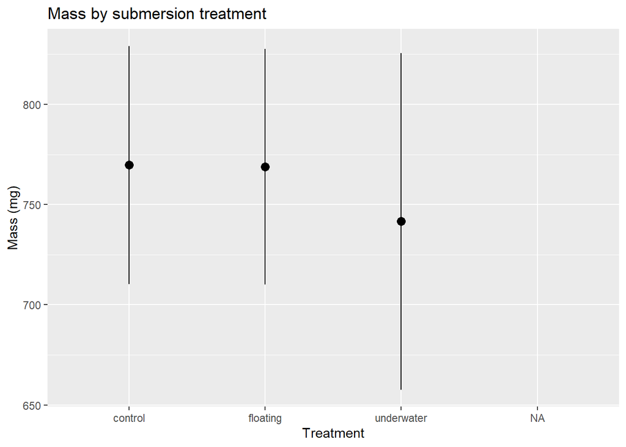

```r
library(Rmisc)
library(ggplot2)
bee_summary <- summarySE(bee_data, measurevar="Weight", groupvars="Submersion")
ggplot(bee_summary, aes(x=Submersion, y=Weight)) +
    geom_point(size=3) +
    geom_errorbar(aes(ymin=Weight - ci, ymax=Weight + ci), width=0) +
    ylab("Mass (mg)") +
    xlab("Treatment") +
    ggtitle("Mass by submersion treatment")
```

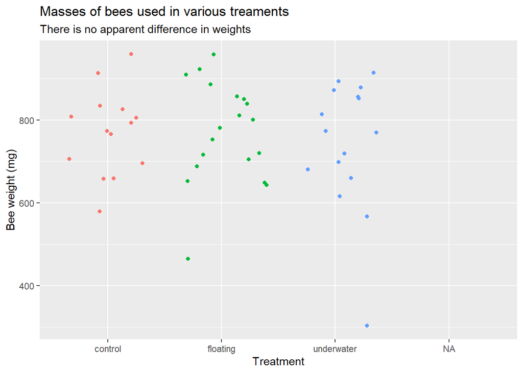

```r
ggplot(bee_data, aes(y=Weight, x=Submersion, color=Submersion)) +
  geom_jitter() +
  labs(title="Masses of bees used in various treaments",
       subtitle = "There is no apparent difference in weights",
       y= "Bee weight (mg)",
       x= "Treatment")+
  guides(color=F)
```

## 6

Another lab group wants to use this data to consider if bees used in the study differed from typical queen weights. A typical queen at the stage used in the study weighs 450 mg.

Investigate the question. Make sure you include

- null hypothesis (1 point)
- alternative hypothesis (1 point)
- explanation for test you will use (1.5 point)
- results from statistical test (1 point)

  ```r
  t.test(bee_data$Weight, mu=450)
  ```

  ```
      One Sample t-test

  data:  bee_data$Weight
  t = 16.971, df = 48, p-value < 2.2e-16
  alternative hypothesis: true mean is not equal to 450
  95 percent confidence interval:
   723.4344 796.9330
  sample estimates:
  mean of x
   760.1837
  ```

- clear explanation of how results relate to your stated hypotheses (1.5 point)

## References

“Hibernating Bumblebee Queens Can Survive Underwater for up to a Week, Study Finds.” n.d. https://www.smithsonianmag.com/smart-news/hibernating-bumblebee-queens-can-survive-underwater-for-up-to-a-week-study-finds-180984175/.

Rondeau, Sabrina, and Nigel E. Raine. 2024. “Unveiling the Submerged Secrets: Bumblebee Queens’ Resilience to Flooding.” *Biology Letters* 20 (4): 20230609. https://doi.org/10.1098/rsbl.2023.0609.